# HUBUNGAN SKOR ALBUMIN-BILIRUBIN (ALBI) PRA-TERAPI DENGAN RESPON RADIOLOGIS TERAPI LENVATINIB DALAM RENTANG 12–16 MINGGU PERTAMA PADA KARSINOMA SEL HATI YANG TIDAK DAPAT DIRESEKSI

# 5 HASIL PENELITIAN DAN PEMBAHASAN

## 5.1 Hasil Penelitian

### 5.1.1 Alur seleksi sampel dan karakteristik subjek penelitian

Penelitian ini mengevaluasi data rekam medis elektronik pasien karsinoma sel hati (KSH) yang menerima terapi sistemik lenvatinib di RSUP Prof. dr. I.G.N.G. Ngoerah Denpasar periode 1 Januari 2023 sampai dengan 31 Desember 2025. Dari 79 pasien dalam populasi terjangkau, sebanyak 74 subjek memenuhi kriteria eligibilitas dan diikutsertakan dalam analisis akhir (jumlah sampel tanpa riwayat terapi sebelumnya (n = 74) memenuhi target minimal (n ≥ 68), sehingga 4 pasien dengan riwayat TACE/reseksi/ablasi dieksklusi), terdiri atas 18 pasien pada kelompok ALBI Derajat 1 dan 56 pasien pada kelompok ALBI Derajat 2–3 (Gambar 5.1).

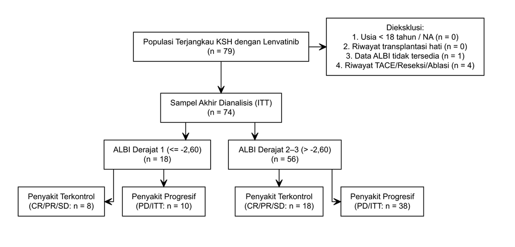

Gambar 5.1 Diagram alur seleksi sampel penelitian berdasarkan skor ALBI pra-terapi dan luaran respon radiologis mRECIST 12–16 minggu (pendekatan ITT)

Uji normalitas Shapiro–Wilk menunjukkan bahwa variabel usia ($p = 0,056$) dan PNI ($p = 0,122$) berdistribusi normal sehingga disajikan dalam bentuk rerata $\pm$ simpang baku (SB), sedangkan albumin, bilirubin total, skor ALBI ($p = 0,002$), AFP, PIVKA-II, kreatinin, dan RDI tidak berdistribusi normal sehingga disajikan dalam bentuk median (rentang interkuartil/IQR). Karakteristik dasar subjek penelitian secara keseluruhan maupun berdasarkan kelompok luaran disajikan pada Tabel 5.1.

Tabel 5.1 Karakteristik Subjek Penelitian Berdasarkan Respon Terapi Lenvatinib 12–16 Minggu

| Karakteristik | Total (n = 74) | Penyakit Terkontrol (n = 26) | Penyakit Progresif (n = 48) | Nilai p |
| --- | --- | --- | --- | --- |
| Usia saat diagnosis (tahun), rerata ± SB | 55,59 ± 11,42 | 53,73 ± 11,45 | 56,60 ± 11,39 | 0,307a |
| **Jenis kelamin, n (%)** |  |  |  |  |
| Perempuan | 17 (23,0) | 7 (26,9) | 10 (20,8) | 0,552d |
| Laki-laki | 57 (77,0) | 19 (73,1) | 38 (79,2) |  |
| **Stadium BCLC, n (%)** |  |  |  |  |
| BCLC C | 54 (73,0) | 19 (73,1) | 35 (72,9) | 0,988d |
| BCLC B | 20 (27,0) | 7 (26,9) | 13 (27,1) |  |
| **Etiologi KSH, n (%)** |  |  |  |  |
| Non-viral | 25 (33,8) | 10 (38,5) | 15 (31,2) | 0,531d |
| Viral | 49 (66,2) | 16 (61,5) | 33 (68,8) |  |
| **Skor Child-Pugh (CTP), n (%)** |  |  |  |  |
| CTP B–C | 29 (39,2) | 8 (30,8) | 21 (43,8) | 0,275d |
| CTP A | 45 (60,8) | 18 (69,2) | 27 (56,2) |  |
| **Status performa ECOG, n (%)** |  |  |  |  |
| ECOG ≥ 2 | 11 (14,9) | 5 (19,2) | 6 (12,5) | 0,502c |
| ECOG 0–1 | 63 (85,1) | 21 (80,8) | 42 (87,5) |  |
| Kreatinin serum (mg/dL), median (IQR) | 0,90 (0,79–1,05) | 0,86 (0,81–1,02) | 0,94 (0,77–1,09) | 0,393b |
| Albumin serum (g/dL), median (IQR) | 3,60 (2,90–4,00) | 3,65 (2,90–4,18) | 3,60 (2,90–3,92) | 0,579b |
| Bilirubin total (mg/dL), median (IQR) | 1,15 (0,70–1,62) | 1,15 (0,70–1,50) | 1,15 (0,67–1,83) | 0,675b |
| Skor ALBI pra-terapi, median (IQR) | -2,22 (-2,51–-1,64) | -2,28 (-2,86–-1,57) | -2,21 (-2,46–-1,67) | 0,655b |
| **Derajat ALBI (1 / 2 / 3), n (%)** |  |  |  |  |
| Derajat 1 | 18 (24,3) | 8 (30,8) | 10 (20,8) | 0,634d |
| Derajat 2 | 40 (54,1) | 13 (50,0) | 27 (56,2) |  |
| Derajat 3 | 16 (21,6) | 5 (19,2) | 11 (22,9) |  |
| **Kategori skor ALBI, n (%)** |  |  |  |  |
| ALBI Derajat 2–3 | 56 (75,7) | 18 (69,2) | 38 (79,2) | 0,342d |
| ALBI Derajat 1 | 18 (24,3) | 8 (30,8) | 10 (20,8) |  |
| Kadar AFP pra-terapi (ng/mL), median (IQR) | 117,28 (6,60–2.000,00) | 23,68 (4,10–591,16) | 560,78 (17,02–4.186,73) | 0,023b |
| **Kategori AFP, n (%)** |  |  |  |  |
| AFP ≥ 200 ng/mL | 36 (48,6) | 9 (34,6) | 27 (56,2) | 0,075d |
| AFP < 200 ng/mL | 38 (51,4) | 17 (65,4) | 21 (43,8) |  |
| Kadar PIVKA-II pra-terapi (mAU/mL), median (IQR) | 28,00 (10,00–42,25) | 42,25 (35,12–123,98) | 5,45 (3,17–7,72) | 0,200b |
| Prognostic Nutritional Index (PNI), rerata ± SB | 42,60 ± 10,05 | 43,55 ± 11,12 | 42,08 ± 9,51 | 0,571a |
| **Kategori PNI, n (%)** |  |  |  |  |
| PNI Buruk (< 49,75) | 55 (74,3) | 17 (65,4) | 38 (79,2) | 0,195d |
| PNI Baik (≥ 49,75) | 19 (25,7) | 9 (34,6) | 10 (20,8) |  |
| **Kriteria Up-to-Seven, n (%)** |  |  |  |  |
| Tidak Sesuai (> 7) | 65 (87,8) | 20 (76,9) | 45 (93,8) | 0,059c |
| Sesuai (≤ 7) | 9 (12,2) | 6 (23,1) | 3 (6,2) |  |
| Relative Dose Intensity 12 minggu (%), median (IQR) | 100,00 (71,43–100,00) | 100,00 (71,43–100,00) | 100,00 (71,43–100,00) | 0,447b |
| **Kategori RDI 12 minggu, n (%)** |  |  |  |  |
| RDI ≤ 66,7% | 15 (20,5) | 5 (19,2) | 10 (21,3) | 0,836d |
| RDI > 66,7% | 58 (79,5) | 21 (80,8) | 37 (78,7) |  |
| **Kategori mCCI, n (%)** |  |  |  |  |
| mCCI Tinggi (≥ 2) | 4 (5,4) | 1 (3,8) | 3 (6,2) | 1,000c |
| mCCI Rendah (0–1) | 70 (94,6) | 25 (96,2) | 45 (93,8) |  |

Keterangan: SB = simpang baku; IQR = rentang interkuartil; <sup>a</sup> uji *t* tidak berpasangan; <sup>b</sup> uji Mann–Whitney; <sup>c</sup> uji *Fisher exact*; <sup>d</sup> uji *Chi-square*.

### 5.1.2 Distribusi respon radiologis terapi lenvatinib 12–16 minggu

Distribusi respon terapi berdasarkan kriteria mRECIST dengan pendekatan *intention-to-treat* (ITT) disajikan pada Tabel 5.2. Penyakit terkontrol dicapai oleh 26 subjek (35,1%), sedangkan 48 subjek (64,9%) mengalami penyakit progresif, termasuk 18 subjek yang meninggal atau mengalami perburukan klinis sebelum sempat menjalani evaluasi CT scan.

Tabel 5.2 Distribusi Respon Radiologis Terapi Lenvatinib 12–16 Minggu Berdasarkan Kriteria mRECIST (Pendekatan ITT)

| Kategori Respon Terapi | n | % |
| --- | --- | --- |
| **Penyakit Terkontrol** | 26 | 35,1 |
| Complete Response (CR) | 2 | 2,7 |
| Partial Response (PR) | 7 | 9,5 |
| Stable Disease (SD) | 17 | 23,0 |
| **Penyakit Progresif** | 48 | 64,9 |
| Progressive Disease (CT Evaluasi) | 30 | 40,5 |
| Meninggal / Tanpa CT (ITT) | 18 | 24,3 |
| **Total** | 74 | 100,0 |

### 5.1.3 Analisis kurva ROC variabel numerik

Kemampuan diskriminasi variabel numerik usia saat diagnosis serta skor ALBI kontinu dalam memprediksi pencapaian penyakit terkontrol dievaluasi melalui kurva ROC (Gambar 5.2; Tabel 5.3). Variabel usia menunjukkan nilai AUC sebesar 0,561 (IK 95% 0,423–0,699; $p = 0,393$) dengan titik potong berbasis indeks Youden sebesar 43 tahun (sensitivitas 23,1%, spesifisitas 91,7%). Skor ALBI kontinu menghasilkan AUC sebesar 0,532 (IK 95% 0,385–0,679; $p = 0,655$) dengan titik potong empiris -2,80. Mengingat interval kepercayaan 95% AUC usia mencakup nilai 0,5, analisis bivariat turut melaporkan titik potong klinis baku 60 tahun sebagai pembanding.

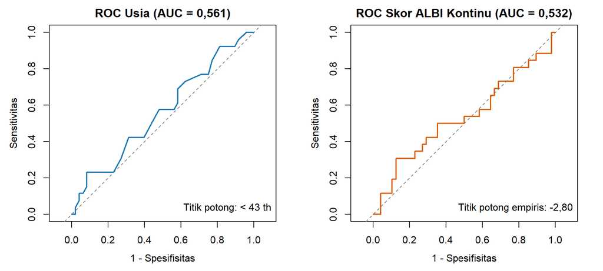

Gambar 5.2 Kurva ROC penentuan titik potong variabel usia (kiri) dan evaluasi diskriminasi skor ALBI kontinu (kanan) dalam memprediksi penyakit terkontrol

Tabel 5.3 Hasil Analisis Kurva ROC Variabel Usia dan Skor ALBI Kontinu terhadap Penyakit Terkontrol

| Variabel | AUC (IK 95%) | Nilai p | Titik Potong | Sensitivitas (%) | Spesifisitas (%) |
| --- | --- | --- | --- | --- | --- |
| Usia saat diagnosis (tahun) | 0,561 (0,423–0,699) | 0,393 | < 43 tahun | 23,1 | 91,7 |
| Skor ALBI pra-terapi (kontinu) | 0,532 (0,385–0,679) | 0,655 | ≤ -2,80 | 30,8 | 87,5 |

### 5.1.4 Analisis bivariat hubungan skor ALBI dan variabel perancu terhadap respon terapi

Pada kelompok ALBI Derajat 1, penyakit terkontrol tercapai pada 8/18 (44,4%), sedangkan pada kelompok ALBI Derajat 2–3 tercapai pada 18/56 (32,1%) (Gambar 5.3). Uji *Chi-square* menghasilkan *Relative Risk* (RR) sebesar 1,38 (IK 95% 0,73–2,63; $p = 0,342$). Rangkuman analisis bivariat seluruh variabel independen dan perancu disajikan pada Tabel 5.4.

Tabel 5.4 Hasil Analisis Bivariat Hubungan Skor ALBI dan Variabel Perancu terhadap Pencapaian Penyakit Terkontrol

| Variabel | n | Perbandingan Kategori | Terkontrol (Kelompok Uji) | Terkontrol (Referensi) | RR (IK 95%) | Nilai p | Metode Uji |
| --- | --- | --- | --- | --- | --- | --- | --- |
| Skor ALBI Pra-Terapi | 74 | ALBI Derajat 1 vs ALBI Derajat 2–3 | 8/18 (44,4%) | 18/56 (32,1%) | 1,38 (0,73–2,63) | 0,342 | Chi-square |
| Usia (titik potong ROC 43 th) | 74 | < 43 tahun vs ≥ 43 tahun | 6/10 (60,0%) | 20/64 (31,2%) | 1,92 (1,03–3,58) | 0,151 | Fisher Exact |
| Usia (titik potong klinis 60 th) | 74 | < 60 tahun vs ≥ 60 tahun | 18/46 (39,1%) | 8/28 (28,6%) | 1,37 (0,69–2,72) | 0,356 | Chi-square |
| Jenis Kelamin | 74 | Laki-laki vs Perempuan | 19/57 (33,3%) | 7/17 (41,2%) | 0,81 (0,41–1,59) | 0,552 | Chi-square |
| Stadium BCLC | 74 | BCLC B vs BCLC C | 7/20 (35,0%) | 19/54 (35,2%) | 0,99 (0,49–2,00) | 0,988 | Chi-square |
| Etiologi KSH | 74 | Viral vs Non-viral | 16/49 (32,7%) | 10/25 (40,0%) | 0,82 (0,44–1,53) | 0,531 | Chi-square |
| Skor Child-Pugh (CTP) | 74 | CTP A vs CTP B–C | 18/45 (40,0%) | 8/29 (27,6%) | 1,45 (0,73–2,89) | 0,275 | Chi-square |
| Status Performa ECOG | 74 | ECOG 0–1 vs ECOG ≥ 2 | 21/63 (33,3%) | 5/11 (45,5%) | 0,73 (0,35–1,53) | 0,502 | Fisher Exact |
| Kadar AFP Pra-Terapi | 74 | AFP < 200 ng/mL vs AFP ≥ 200 ng/mL | 17/38 (44,7%) | 9/36 (25,0%) | 1,79 (0,92–3,49) | 0,075 | Chi-square |
| Prognostic Nutritional Index (PNI) | 74 | PNI Baik (≥ 49,75) vs PNI Buruk (< 49,75) | 9/19 (47,4%) | 17/55 (30,9%) | 1,53 (0,83–2,84) | 0,195 | Chi-square |
| Beban Tumor (Up-to-Seven) | 74 | Sesuai (≤ 7) vs Tidak Sesuai (> 7) | 6/9 (66,7%) | 20/65 (30,8%) | 2,17 (1,20–3,90) | 0,059 | Fisher Exact |
| Komorbiditas (mCCI) | 74 | mCCI Rendah (0–1) vs mCCI Tinggi (≥ 2) | 25/70 (35,7%) | 1/4 (25,0%) | 1,43 (0,25–8,03) | 1,000 | Fisher Exact |
| Relative Dose Intensity (RDI 12 Minggu) | 73 | RDI > 66,7% vs RDI ≤ 66,7% | 21/58 (36,2%) | 5/15 (33,3%) | 1,09 (0,49–2,40) | 0,836 | Chi-square |

Keterangan: RR = relative risk untuk mencapai penyakit terkontrol (CR/PR/SD); PIVKA-II tidak dimasukkan ke uji inferensial karena kelengkapan data < 10%.

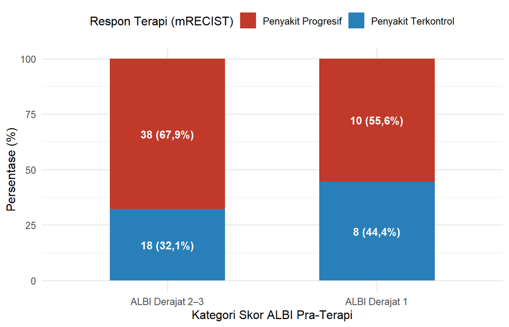

Gambar 5.3 Perbandingan proporsi penyakit terkontrol dan penyakit progresif berdasarkan kategori skor ALBI pra-terapi

### 5.1.5 Analisis multivariat regresi logistik biner dan evaluasi multikolinearitas

Untuk menjaga rasio *events per variable* serta mencegah kolinearitas komponen biokimia antara skor ALBI, CTP, dan PNI, model multivariat utama disusun secara *parsimonious* dengan memasukkan skor ALBI pra-terapi bersama beban tumor (*Up-to-Seven*) dan kadar AFP ($n = 74$). Setelah penyesuaian, ALBI Derajat 1 menunjukkan *adjusted Odds Ratio* (aOR) sebesar 1,73 (IK 95% 0,56–5,36; $p = 0,341$) dengan nilai VIF maksimum 1,02 (Tabel 5.5; Tabel 5.6; Gambar 5.4). Perbandingan kinerja model utama terhadap model berbasis CTP serta model penuh (seluruh kandidat $p < 0{,}25$) disajikan pada Tabel 5.7.

Tabel 5.5 Hasil Analisis Regresi Logistik Biner Multivariat Prediktor Penyakit Terkontrol (Model Parsimonious)

| Variabel Prediktor | B | SE | Adjusted OR (IK 95%) | Nilai p |
| --- | --- | --- | --- | --- |
| ALBI Derajat 1 (vs 2–3) | 0,549 | 0,576 | 1,73 (0,56–5,36) | 0,341 |
| Up-to-Seven ≤ 7 (vs > 7) | 1,351 | 0,775 | 3,86 (0,85–17,62) | 0,081 |
| AFP < 200 ng/mL (vs ≥ 200) | 0,724 | 0,524 | 2,06 (0,74–5,76) | 0,167 |

Keterangan: B = koefisien regresi; SE = standard error; OR = odds ratio; IK = interval kepercayaan. Uji Omnibus p = 0,066; Nagelkerke $R^2$ = 0,128; uji Hosmer–Lemeshow p = 0,133; ketepatan klasifikasi 68,9%; AUC model = 0,674. Variabel dependen dikodekan 0 = penyakit progresif dan 1 = penyakit terkontrol; kategori referensi adalah ALBI Derajat 2–3, Up-to-Seven > 7, dan AFP ≥ 200 ng/mL.

Tabel 5.6 Evaluasi Multikolinearitas Model Multivariat Utama Berdasarkan Variance Inflation Factor (VIF)

| Variabel | VIF | Status |
| --- | --- | --- |
| Skor ALBI Pra-Terapi | 1,00 | Aman (< 5) |
| Beban Tumor (Up-to-Seven) | 1,02 | Aman (< 5) |
| Kadar AFP Pra-Terapi | 1,02 | Aman (< 5) |

Tabel 5.7 Perbandingan Kinerja Model Multivariat Utama (ALBI), Model Pembanding (CTP), dan Model Penuh

| Model | n | Prediktor | aOR Fungsi Hati (IK 95%) | Nilai p | AIC | AUC | VIF Maks |
| --- | --- | --- | --- | --- | --- | --- | --- |
| Model Utama (Parsimonious): ALBI + Up-to-Seven + AFP | 74 | 3 | 1,73 (0,56–5,36) | 0,341 | 96,7 | 0,674 | 1,02 |
| Model Pembanding (CTP): CTP + Up-to-Seven + AFP | 74 | 3 | 1,86 (0,64–5,42) | 0,253 | 96,3 | 0,681 | 1,03 |
| Model Penuh (Semua kandidat p < 0,25) | 74 | 5 | 1,26 (0,22–7,23) | 0,796 | 97,8 | 0,701 | 2,53 |

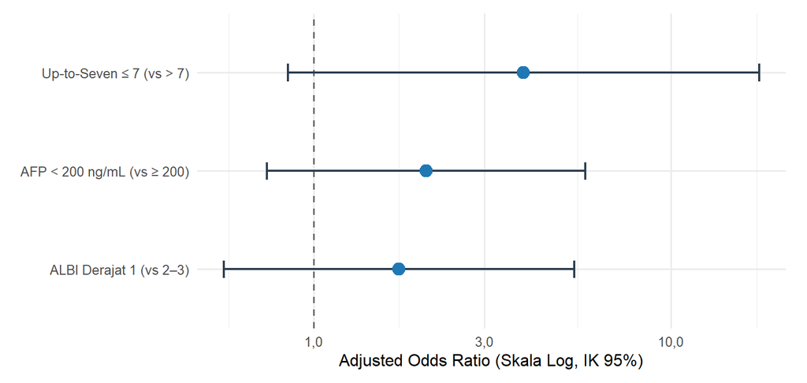

Gambar 5.4 Forest plot Adjusted Odds Ratio (aOR) dan IK 95% dari model regresi logistik biner multivariat utama

### 5.1.6 Analisis sensitivitas (mALBI, per-protocol, dan mortalitas dini)

Analisis sensitivitas mengevaluasi stratifikasi *modified* ALBI (mALBI Derajat 1–2a $\le -2{,}27$ vs 2b–3 $> -2{,}27$), subgrup *per-protocol* pasien yang menjalani evaluasi CT scan 12–16 minggu ($n = 56$), serta luaran mortalitas dini sebelum sempat menjalani evaluasi CT (Tabel 5.8). Setelah dikontrol dengan kriteria *Up-to-Seven* dan AFP, mALBI 1–2a menunjukkan aOR sebesar 1,06 (0,38–2,94) ($p = 0,905$).

Tabel 5.8 Ringkasan Analisis Sensitivitas Stratifikasi mALBI, Subgrup Per-Protocol CT, dan Mortalitas Dini

| Analisis Sensitivitas | n | Perbandingan | Kejadian (Kelompok Uji) | Kejadian (Referensi) | RR (IK 95%) | Nilai p | Uji |
| --- | --- | --- | --- | --- | --- | --- | --- |
| mALBI (titik potong -2,27) — ITT | 74 | mALBI 1–2a (≤ -2,27) vs mALBI 2b–3 (> -2,27) | 13/34 (38,2%) | 13/40 (32,5%) | 1,18 (0,63–2,18) | 0,607 | Chi-square |
| ALBI Derajat 1 vs 2–3 — Per-Protocol CT | 56 | ALBI Derajat 1 vs ALBI Derajat 2–3 | 8/15 (53,3%) | 18/41 (43,9%) | 1,21 (0,68–2,18) | 0,531 | Chi-square |
| mALBI 1–2a vs 2b–3 — Per-Protocol CT | 56 | mALBI 1–2a (≤ -2,27) vs mALBI 2b–3 (> -2,27) | 13/28 (46,4%) | 13/28 (46,4%) | 1,00 (0,57–1,76) | 1,000 | Chi-square |
| ALBI Derajat 1 vs 2–3 — Mortalitas Dini/Tanpa CT | 74 | ALBI Derajat 1 vs ALBI Derajat 2–3 | 3/18 (16,7%) | 15/56 (26,8%) | 0,62 (0,20–1,91) | 0,533 | Fisher Exact |
| mALBI 1–2a vs 2b–3 — Mortalitas Dini/Tanpa CT | 74 | mALBI 1–2a (≤ -2,27) vs mALBI 2b–3 (> -2,27) | 6/34 (17,6%) | 12/40 (30,0%) | 0,59 (0,25–1,40) | 0,217 | Chi-square |